# 22_poisson_distribution slides

### The Poisson Distribution

- Used in experiments that model the numbers of events in a fixed period of time or a fixed area of space
- Ex.:
  - Number of daily accidents on the H1
  - Number of people who enter a grocery store every hour
  - Number of childbirths in Hawaii every day
  - Number of chocolate chips in a cookie
  - etc.

#### Properties of the Poisson Distribution

- Poisson has only one parameter that determines its shape and location.
  - The parameter is referrd to as $\lambda$
- A random variable $X$ is Poisson, written $X \sim Poisson(\lambda)$, if:
  - $X$ is the number of events in a given time period or space area
    - Countably infinite positive values [0, 1, ... ]
  - The events are independent (The occurrent of events does not increase the likelihood of other events occurring)
  - The mean and the variance of a Poisson are represented using the same parameter $\lambda$.
- The $pmf$ of a Poisson is:

$$ p(X=x) = \frac{e^{_\lambda} \lambda^x}{x!} $$

#### Example

- If the clientele visiting a store per hour follows a Poisson distribution with $\lambda = 10$.
- The probability distribution of the random variable $X$ representing the number of clients in the store is:

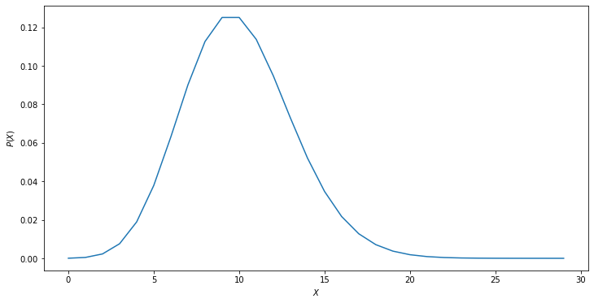

```python
plt.figure(figsize=(12,6))
x = np.arange(0, 30, 1)
pmfs_x = poisson.pmf(x, 10)
plt.plot(x, pmfs_x,)
_ = plt.xlabel("$X$")
_ = plt.ylabel("$P(X)$")
```

### Example

- If the clientele visiting a store per hour follows a Poisson distribution with $\lambda = 10$.
- The probability that $x$, for $x \in \{0, 5, 10, 15, 20, 30, 50\}$) clients visit the store tomorrow between 3 PM and 4PM is:

[output not shown]

```python
for x in [0, 5, 10, 15, 20, 30, 50]:
    print( "The pmf of x = %d is %1.20f " % (x, poisson.pmf(x, 10)))
```

```
The pmf of x = 0 is 0.00004539992976248485
The pmf of x = 5 is 0.03783327480207079180
The pmf of x = 10 is 0.12511003572113371662
The pmf of x = 15 is 0.03471806963068424512
The pmf of x = 20 is 0.00186608131399877415
The pmf of x = 30 is 0.00000017115717355368
The pmf of x = 50 is 0.00000000000000000015
```

### Link between the mean and the variance

- As mentioned, the mean and variance are both modeled with the same parameter $\lambda$
  - What is the significance of this statement?

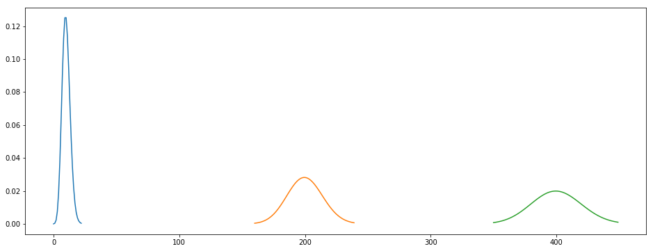

```python
plt.figure(figsize=(16,6))

x = np.arange(0, 23, 1)
pmfs_x = poisson.pmf(x, 10)
plt.plot(x, pmfs_x)

x = np.arange(160, 240, 1)
pmfs_x = poisson.pmf(x, 200)
plt.plot(x, pmfs_x)


x = np.arange(350, 450, 1)
pmfs_x = poisson.pmf(x, 400)
plt.plot(x, pmfs_x)
```